# Final project

## **Building the model**

We want to predict the fulfillment or not fulfillment of the reservations. The outcome is binomial categorical variable “Fulfillment” and it can be “Yes” this means the clients stayed and check out in the hotel, and “No” this means that the clients canceled the reservation or did not show up. Based on the visualization of the data. We have selected several variables as predictors. We will use binomial logistic regression.

First we build a model with all predictor variables selected in the dataset.

```r
# Complex model with all selected variables
all_city_m_c <- glm(fulfillment ~ lead_time + is_repeated_guest + previous_cancellations + deposit_type  +  + total_of_special_requests + child_comp + season, data = city_hotel, family = "binomial")
summary(all_city_m_c)
```

```
##
## Call:
## glm(formula = fulfillment ~ lead_time + is_repeated_guest + previous_cancellations +
##     deposit_type + +total_of_special_requests + child_comp +
##     season, family = "binomial", data = city_hotel)
##
## Deviance Residuals:
##     Min       1Q   Median       3Q      Max
## -2.6905  -0.7379   0.6178   0.8579   5.2024
##
## Coefficients:
##                             Estimate Std. Error z value Pr(>|z|)
## (Intercept)                7.620e-01  1.941e-02  39.270  < 2e-16 ***
## lead_time                 -2.881e-03  9.568e-05 -30.106  < 2e-16 ***
## is_repeated_guest1         1.502e+00  8.049e-02  18.655  < 2e-16 ***
## previous_cancellations    -1.200e+00  4.619e-02 -25.977  < 2e-16 ***
## deposit_typeNon Refund    -6.409e+00  2.046e-01 -31.326  < 2e-16 ***
## deposit_typeRefundable    -1.711e+00  5.074e-01  -3.372 0.000747 ***
## total_of_special_requests  5.284e-01  1.235e-02  42.785  < 2e-16 ***
## child_compYes             -3.981e-01  3.143e-02 -12.666  < 2e-16 ***
## seasonSummer               4.803e-02  2.266e-02   2.120 0.034036 *
## seasonFall                 2.720e-01  2.510e-02  10.836  < 2e-16 ***
## seasonWinter              -1.184e-02  2.722e-02  -0.435 0.663585
## ---
## Signif. codes:  0 '***' 0.001 '**' 0.01 '*' 0.05 '.' 0.1 ' ' 1
##
## (Dispersion parameter for binomial family taken to be 1)
##
##     Null deviance: 107786  on 79325  degrees of freedom
## Residual deviance:  77493  on 79315  degrees of freedom
## AIC: 77515
##
## Number of Fisher Scoring iterations: 8
```

```r
# Check Multicollinearity
car::vif(all_city_m_c)
```

```
##                               GVIF Df GVIF^(1/(2*Df))
## lead_time                 1.097237  1        1.047491
## is_repeated_guest         1.278239  1        1.130592
## previous_cancellations    1.292421  1        1.136847
## deposit_type              1.002558  2        1.000639
## total_of_special_requests 1.021981  1        1.010931
## child_comp                1.028747  1        1.014272
## season                    1.100603  3        1.016105
```

```r
# All predictors with values lower than 3
```

We build a reduced model without season variable

```r
# Reduced model without season
city_m_c2 <- glm(fulfillment ~ deposit_type + is_repeated_guest + previous_cancellations + lead_time +  total_of_special_requests + child_comp, data = city_hotel, family = "binomial")
summary(city_m_c2)
```

```
##
## Call:
## glm(formula = fulfillment ~ deposit_type + is_repeated_guest +
##     previous_cancellations + lead_time + total_of_special_requests +
##     child_comp, family = "binomial", data = city_hotel)
##
## Deviance Residuals:
##     Min       1Q   Median       3Q      Max
## -2.6078  -0.7487   0.6242   0.8549   5.1247
##
## Coefficients:
##                             Estimate Std. Error z value Pr(>|z|)
## (Intercept)                0.8356055  0.0140133   59.63  < 2e-16 ***
## deposit_typeNon Refund    -6.4035236  0.2045592  -31.30  < 2e-16 ***
## deposit_typeRefundable    -1.7080922  0.5083947   -3.36  0.00078 ***
## is_repeated_guest1         1.4799234  0.0799790   18.50  < 2e-16 ***
## previous_cancellations    -1.1739954  0.0457296  -25.67  < 2e-16 ***
## lead_time                 -0.0028423  0.0000919  -30.93  < 2e-16 ***
## total_of_special_requests  0.5254184  0.0123062   42.70  < 2e-16 ***
## child_compYes             -0.4186615  0.0312561  -13.39  < 2e-16 ***
## ---
## Signif. codes:  0 '***' 0.001 '**' 0.01 '*' 0.05 '.' 0.1 ' ' 1
##
## (Dispersion parameter for binomial family taken to be 1)
##
##     Null deviance: 107786  on 79325  degrees of freedom
## Residual deviance:  77644  on 79318  degrees of freedom
## AIC: 77660
##
## Number of Fisher Scoring iterations: 8
```

```r
# Model fit
fit_models <- anova(all_city_m_c, city_m_c2, test = "Chisq")
print(fit_models)
```

```
## Analysis of Deviance Table
##
## Model 1: fulfillment ~ lead_time + is_repeated_guest + previous_cancellations +
##     deposit_type + +total_of_special_requests + child_comp +
##     season
## Model 2: fulfillment ~ deposit_type + is_repeated_guest + previous_cancellations +
##     lead_time + total_of_special_requests + child_comp
##   Resid. Df Resid. Dev Df Deviance  Pr(>Chi)
## 1     79315      77493
## 2     79318      77644 -3  -150.92 < 2.2e-16 ***
## ---
## Signif. codes:  0 '***' 0.001 '**' 0.01 '*' 0.05 '.' 0.1 ' ' 1
```

```r
# BIC
BIC(all_city_m_c, city_m_c2)
```

```
##              df      BIC
## all_city_m_c 11 77617.13
## city_m_c2     8 77734.20
```

```r
# AIC
AIC(all_city_m_c, city_m_c2)
```

```
##              df      AIC
## all_city_m_c 11 77515.03
## city_m_c2     8 77659.95
```

Based on the coefficients of the reduced model all the selected predictors: Type of deposit, being a repeated guest, previous cancellations, lead time, special requests and presence of children contributed significantly to the likelihood of fulfillment of the reservation.

### **Null model**

To asses model fit, we will compare the reduce model against a model without any predictors, and only the intercept

```r
# Create a null model, with only the intercept
city_m_dep <- glm(fulfillment ~ 1, data = city_hotel, family = "binomial")
summary(city_m_dep)
```

```
##
## Call:
## glm(formula = fulfillment ~ 1, family = "binomial", data = city_hotel)
##
## Deviance Residuals:
##    Min      1Q  Median      3Q     Max
## -1.322  -1.322   1.039   1.039   1.039
##
## Coefficients:
##             Estimate Std. Error z value Pr(>|z|)
## (Intercept)   0.3341     0.0072    46.4   <2e-16 ***
## ---
## Signif. codes:  0 '***' 0.001 '**' 0.01 '*' 0.05 '.' 0.1 ' ' 1
##
## (Dispersion parameter for binomial family taken to be 1)
##
##     Null deviance: 107786  on 79325  degrees of freedom
## Residual deviance: 107786  on 79325  degrees of freedom
## AIC: 107788
##
## Number of Fisher Scoring iterations: 4
```

AIC: 107788 Residual deviance: 107786

### **Model fit**

```r
# Compare models
fit_models <- anova(city_m_dep, city_m_c2, test = "Chisq")
print(fit_models)
```

```
## Analysis of Deviance Table
##
## Model 1: fulfillment ~ 1
## Model 2: fulfillment ~ deposit_type + is_repeated_guest + previous_cancellations +
##     lead_time + total_of_special_requests + child_comp
##   Resid. Df Resid. Dev Df Deviance  Pr(>Chi)
## 1     79325     107786
## 2     79318      77644  7    30142 < 2.2e-16 ***
## ---
## Signif. codes:  0 '***' 0.001 '**' 0.01 '*' 0.05 '.' 0.1 ' ' 1
```

```r
# When comparing the models, reduced complex model represent a significant improvement compared to the null model

BIC(city_m_dep, city_m_c2)
```

```
##            df      BIC
## city_m_dep  1 107797.2
## city_m_c2   8  77734.2
```

```r
# BIC values for null model 107797
# BIC values for complex model 77734

AIC(city_m_dep, city_m_c2)
```

```
##            df       AIC
## city_m_dep  1 107787.88
## city_m_c2   8  77659.95
```

```r
# AIC values for simple model 107787
# AIC values for complex model 77659

# Likelihood radio test
fit3 <- lrtest(city_m_dep, city_m_c2)
print(fit3)
```

```
## Likelihood ratio test
##
## Model 1: fulfillment ~ 1
## Model 2: fulfillment ~ deposit_type + is_repeated_guest + previous_cancellations +
##     lead_time + total_of_special_requests + child_comp
##   #Df LogLik Df Chisq Pr(>Chisq)
## 1   1 -53893
## 2   8 -38822  7 30142  < 2.2e-16 ***
## ---
## Signif. codes:  0 '***' 0.001 '**' 0.01 '*' 0.05 '.' 0.1 ' ' 1
```

```r
# Chi squared 30142 p. <0.000
#VIF
car::vif(city_m_c2)
```

```
##                               GVIF Df GVIF^(1/(2*Df))
## deposit_type              1.002142  2        1.000535
## is_repeated_guest         1.274757  1        1.129051
## previous_cancellations    1.281567  1        1.132063
## lead_time                 1.014108  1        1.007029
## total_of_special_requests 1.020741  1        1.010317
## child_comp                1.020266  1        1.010082
```

```r
# There is no multicollinearity, all variables have values below 3

# Table of deviance
anova(city_m_c2, test="Chisq")
```

```
## Analysis of Deviance Table
##
## Model: binomial, link: logit
##
## Response: fulfillment
##
## Terms added sequentially (first to last)
##
##
##                           Df Deviance Resid. Df Resid. Dev  Pr(>Chi)
## NULL                                      79325     107786
## deposit_type               2  25726.5     79323      82059 < 2.2e-16 ***
## is_repeated_guest          1    131.2     79322      81928 < 2.2e-16 ***
## previous_cancellations     1   1286.7     79321      80642 < 2.2e-16 ***
## lead_time                  1    897.1     79320      79744 < 2.2e-16 ***
## total_of_special_requests  1   1926.5     79319      77818 < 2.2e-16 ***
## child_comp                 1    174.0     79318      77644 < 2.2e-16 ***
## ---
## Signif. codes:  0 '***' 0.001 '**' 0.01 '*' 0.05 '.' 0.1 ' ' 1
```

Based on the model comparison, the reduced model is the better fit against a null model. We will continue assessing the fitness of the logistic regression model. First we need to interpret the coefficients of the selected model.

```r
#Required package
library(coefplot)

# Check regression coefficients on the selected model
summary(city_m_c2)
```

```
##
## Call:
## glm(formula = fulfillment ~ deposit_type + is_repeated_guest +
##     previous_cancellations + lead_time + total_of_special_requests +
##     child_comp, family = "binomial", data = city_hotel)
##
## Deviance Residuals:
##     Min       1Q   Median       3Q      Max
## -2.6078  -0.7487   0.6242   0.8549   5.1247
##
## Coefficients:
##                             Estimate Std. Error z value Pr(>|z|)
## (Intercept)                0.8356055  0.0140133   59.63  < 2e-16 ***
## deposit_typeNon Refund    -6.4035236  0.2045592  -31.30  < 2e-16 ***
## deposit_typeRefundable    -1.7080922  0.5083947   -3.36  0.00078 ***
## is_repeated_guest1         1.4799234  0.0799790   18.50  < 2e-16 ***
## previous_cancellations    -1.1739954  0.0457296  -25.67  < 2e-16 ***
## lead_time                 -0.0028423  0.0000919  -30.93  < 2e-16 ***
## total_of_special_requests  0.5254184  0.0123062   42.70  < 2e-16 ***
## child_compYes             -0.4186615  0.0312561  -13.39  < 2e-16 ***
## ---
## Signif. codes:  0 '***' 0.001 '**' 0.01 '*' 0.05 '.' 0.1 ' ' 1
##
## (Dispersion parameter for binomial family taken to be 1)
##
##     Null deviance: 107786  on 79325  degrees of freedom
## Residual deviance:  77644  on 79318  degrees of freedom
## AIC: 77660
##
## Number of Fisher Scoring iterations: 8
```

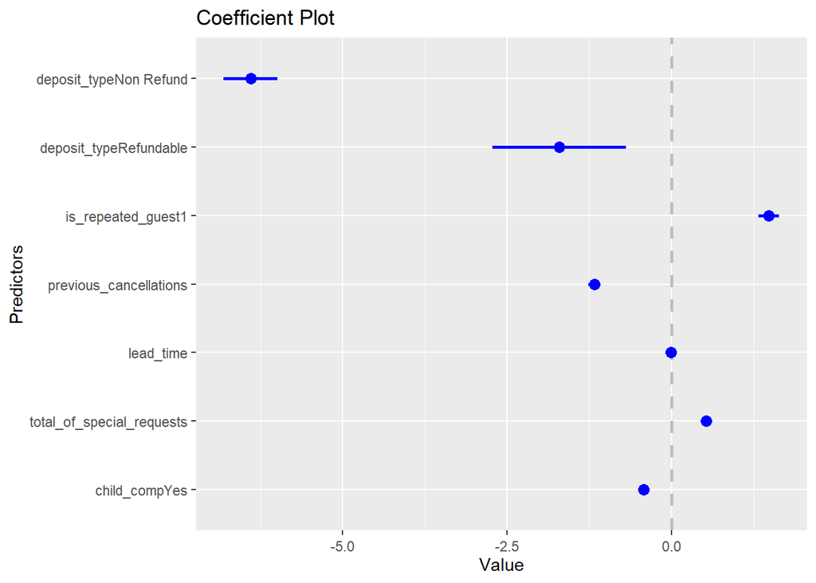

```r
# Plotting the coefficients
coefplot(city_m_c2, innerCI=2, outerCI=0,
         ylab= "Predictors",
         intercept = FALSE, decreasing = TRUE)
```

```r
# Because in logistic regression they are difficult to interpret, we exponentiate them
exp(coef(city_m_c2))
```

```
##               (Intercept)    deposit_typeNon Refund    deposit_typeRefundable
##               2.306209954               0.001655713               0.181211174
##        is_repeated_guest1    previous_cancellations                 lead_time
##               4.392609203               0.309129376               0.997161759
## total_of_special_requests             child_compYes
##               1.691166252               0.657926884
```

```r
# 95% Confidence intervals for the coefficients
exp(confint(city_m_c2))
```

```
##                                 2.5 %      97.5 %
## (Intercept)               2.243794212 2.370498325
## deposit_typeNon Refund    0.001077302 0.002412669
## deposit_typeRefundable    0.061853604 0.469717781
## is_repeated_guest1        3.763249910 5.149349592
## previous_cancellations    0.282369211 0.337809873
## lead_time                 0.996982141 0.997341357
## total_of_special_requests 1.650972842 1.732568025
## child_compYes             0.618901817 0.699576518
```

```r
# Table according to APA format
tab_model(city_m_c2, show.aic = TRUE, show.loglik = TRUE,
          string.ci = "95% CI",
          show.stat = TRUE, robust = TRUE,
          dv.labels = "Fulfillment of reservations in City Hotel",
          pred.labels = c("(Intercept)",
                          "Non-refundable deposit",
                          "Refundable deposit",
                          "Repeated guest",
                          "Previous cancellations",
                          "Lead time",
                          "Special requests",
                          "Children compaignions"))
```

|  | Fulfillment of reservations in City Hotel |  |  |  |
| --- | --- | --- | --- | --- |
| Predictors | Odds Ratios | 95% CI | Statistic | p |
| (Intercept) | 2.31 | 2.24 – 2.37 | 60.79 | **<0.001** |
| Non-refundable deposit | 0.00 | 0.00 – 0.00 | -31.28 | **<0.001** |
| Refundable deposit | 0.18 | 0.06 – 0.57 | -2.90 | **0.004** |
| Repeated guest | 4.39 | 3.59 – 5.37 | 14.40 | **<0.001** |
| Previous cancellations | 0.31 | 0.24 – 0.40 | -9.00 | **<0.001** |
| Lead time | 1.00 | 1.00 – 1.00 | -30.25 | **<0.001** |
| Special requests | 1.69 | 1.65 – 1.74 | 40.04 | **<0.001** |
| Children compaignions | 0.66 | 0.62 – 0.70 | -13.65 | **<0.001** |
| Observations | 79326 |  |  |  |
| R<sup>2</sup> Tjur | 0.319 |  |  |  |
| AIC | 77659.953 |  |  |  |
| log-Likelihood | -38821.977 |  |  |  |

- The odds of fulfilling the reservation are increased by 4.39 when the client is a repeated guest than when he is not a repeated guest
- Per one unit increase in special requests there is a 1.69 increase in the odds of fulfillment.
- Odds of fulfillment are smaller by a factor of .18 when the deposit is refundable, .001 when the deposit is not refundable compare to when there is not deposit, this last odds ratio does not allow us to properly estimate the effect of non refundable deposit type
- Odds of fulfillment are smaller by a factor of .30 when there has being previous cancellations compared to no previous cancellations.
- In lead time, the value es .99, extremely close to 1, we can interpret it as there is not effect of lead time on fulfillment.
- Finally, odds of fulfillment are smaller by a factor of .66 when there are children companions compared to no children present.

### **Odds ratio as percentage**

```r
odds_perc <- (exp(city_m_c2$coefficients[-1])-1)*100
odds_perc
```

```
##    deposit_typeNon Refund    deposit_typeRefundable        is_repeated_guest1
##               -99.8344287               -81.8788826               339.2609203
##    previous_cancellations                 lead_time total_of_special_requests
##               -69.0870624                -0.2838241                69.1166252
##             child_compYes
##               -34.2073116
```

- The odds of fulfillment of the reservation increased by 69% where there are special requests and by 339% when there have been in the hotel before.
- The odds of fulfillment decreased by 81% when there is a refundable deposit compared to when there is no deposit
- The odds of fulfillment decreased by 69% when there have been previous cancellations, by 34% when children are companions

### **Assessment the impact of predictors on the probability of an outcome**

We will use the resort hotel dataset, to test the prediction of the model

```r
# Take the resort hotel dataset as a prediction set

testdata <- resort_hotel %>%
  select(deposit_type, is_repeated_guest, previous_cancellations, lead_time, total_of_special_requests, child_comp)

view(testdata)

# Use testdata and prediction equation to obtain probabilities
testdata$prob <- predict(city_m_c2, newdata=testdata, type="response")
view(testdata)

# Test overdispersion
deviance(city_m_c2)/df.residual(city_m_c2)
```

```
## [1] 0.9788945
```

```r
# Overdispersion is not larger than 1, which means we do not have overdispersion.
```

We want to obtain the most likely outcome, odds ratio and the logs odd ratio

```r
prediction_data <- testdata %>%
mutate(
has_fulfill = predict(city_m_c2, testdata, type = "response"),
most_likely_response = round(has_fulfill),
odds_ratio = has_fulfill / (1 - has_fulfill), log_odds_ratio = log(odds_ratio),
log_odds_ratio2 = predict(city_m_c2, testdata))

view(prediction_data)
```

### **Accuracy and error rate**

```r
# Required packages
library(yardstick)
library(gmodels)

# Create objects with the fulfillment variable from the original dataset and the predicted outcome from the model
actual_response <- city_hotel$fulfillment
predicted_response <- round(fitted(city_m_c2))

# Create the confusion matrix with the CrossTable function from the gmodels package
confusion_m <- CrossTable(actual_response, predicted_response)
```

```
##
##
##    Cell Contents
## |-------------------------|
## |                       N |
## | Chi-square contribution |
## |           N / Row Total |
## |           N / Col Total |
## |         N / Table Total |
## |-------------------------|
##
##
## Total Observations in Table:  79326
##
##
##                 | predicted_response
## actual_response |         0 |         1 | Row Total |
## ----------------|-----------|-----------|-----------|
##              No |     14833 |     18265 |     33098 |
##                 | 10260.287 |  2556.751 |           |
##                 |     0.448 |     0.552 |     0.417 |
##                 |     0.937 |     0.288 |           |
##                 |     0.187 |     0.230 |           |
## ----------------|-----------|-----------|-----------|
##             Yes |       991 |     45237 |     46228 |
##                 |  7346.088 |  1830.564 |           |
##                 |     0.021 |     0.979 |     0.583 |
##                 |     0.063 |     0.712 |           |
##                 |     0.012 |     0.570 |           |
## ----------------|-----------|-----------|-----------|
##    Column Total |     15824 |     63502 |     79326 |
##                 |     0.199 |     0.801 |           |
## ----------------|-----------|-----------|-----------|
##
##
```

```r
confusion_m
```

```
## $t
##      y
## x         0     1
##   No  14833 18265
##   Yes   991 45237
##
## $prop.row
##      y
## x              0          1
##   No  0.44815397 0.55184603
##   Yes 0.02143722 0.97856278
##
## $prop.col
##      y
## x              0          1
##   No  0.93737361 0.28762874
##   Yes 0.06262639 0.71237126
##
## $prop.tbl
##      y
## x              0          1
##   No  0.18698787 0.23025238
##   Yes 0.01249275 0.57026700
```

```r
# Acurracy
accuracy <- (14833 + 45237) / (14833 + 991 + 18265 + 45237)

print(accuracy)
```

```
## [1] 0.7572549
```

```r
# 0.76 which represents 76% of acurracy of prediction

# Error rate

error_r = (991 + 18265) / (14833 + 991 + 18265 + 45237)

print(error_r)
```

```
## [1] 0.2427451
```

```r
# 0. 24 which represents a 24% error rate of prediction
```

### **ROC Curve**

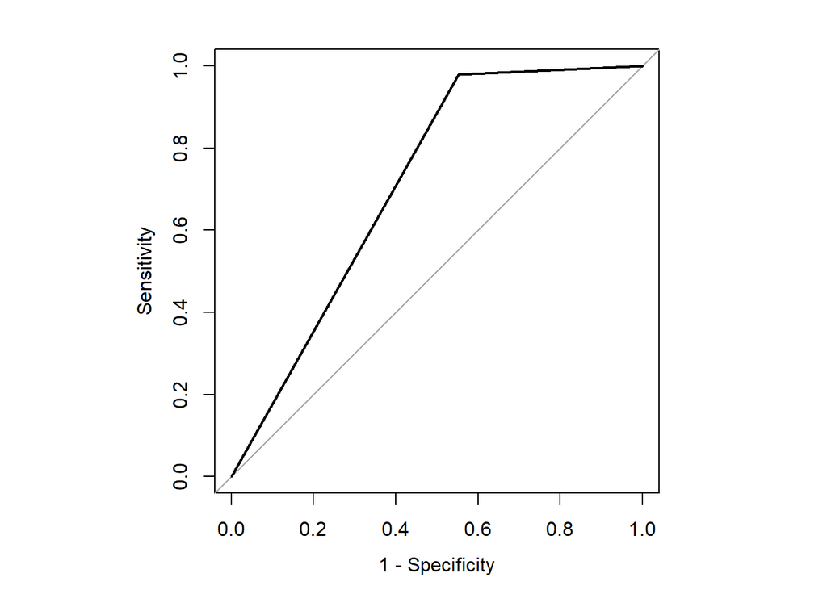

```
##
## Call:
## roc.default(response = actual_response, predictor = predicted_response,     plot = TRUE, legacy.axes = TRUE)
##
## Data: predicted_response in 33098 controls (actual_response No) < 46228 cases (actual_response Yes).
## Area under the curve: 0.7134
```

```r
# Required packages
library(pROC)

# Margin smaller
par(pty = "s")
# ROC curve
roc(actual_response, predicted_response, plot = TRUE, legacy.axes = TRUE)
```

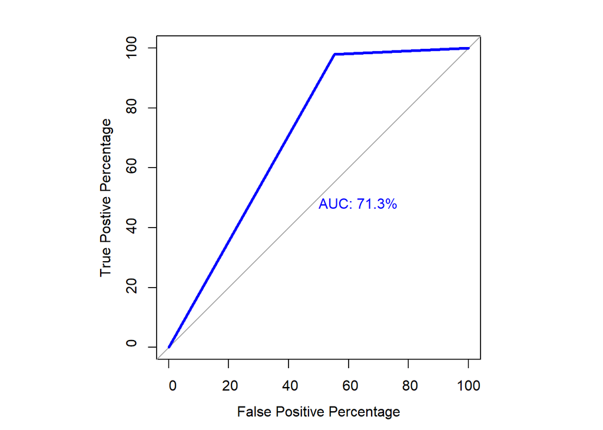

```
##
## Call:
## roc.default(response = actual_response, predictor = predicted_response,     percent = TRUE, plot = TRUE, legacy.axes = TRUE, xlab = "False Positive Percentage",     ylab = "True Postive Percentage", col = "blue", lwd = 3,     print.auc = TRUE)
##
## Data: predicted_response in 33098 controls (actual_response No) < 46228 cases (actual_response Yes).
## Area under the curve: 71.34%
```

```r
# ROC curve with percentage and AUC
roc(actual_response, predicted_response, plot = TRUE, legacy.axes = TRUE, percent = TRUE, xlab="False Positive Percentage", ylab="True Postive Percentage", col="blue", lwd=3, print.auc = TRUE)
```

```r
# Resetting margins
par(pty = "m")
```

## **Conclusions**

- Based on the analysis we can recommend to both hotels to focus their advertisement on previous guests, as well offering special accommodations, and adjustable packages to serve the needs of the clients. Since being a repeated guest and special request increase the odds of fulfillment of the reservation.
- Hotels can reward client fidelity, when several reservations have been fulfilled, and in this way increasing the chances of clients coming back and avoiding several cancellations.
- When children are companions there is a decrease in the odds of fulfillment, this could be caused by multiple factors, children get sick, they need special installations,etc. The hotels can target single people, couples without children, retired people, if they want to increase their chances of fulfillment.